# Ultimate Inc Data Science Challenge

## Exploratory Data Analysis

```python
import pandas as pd
logins_df = pd.read_json("logins.json")
```

```python
logins_df.info()
```

```
<class 'pandas.core.frame.DataFrame'>
RangeIndex: 93142 entries, 0 to 93141
Data columns (total 1 columns):
login_time    93142 non-null datetime64[ns]
dtypes: datetime64[ns](1)
memory usage: 727.8 KB
```

```python
logins_df.describe()
```

|  | login_time |
| --- | --- |
| count | 93142 |
| unique | 92265 |
| top | 1970-02-12 11:16:53 |
| freq | 3 |
| first | 1970-01-01 20:12:16 |
| last | 1970-04-13 18:57:38 |

```python
# Data range
min(logins_df.login_time), max(logins_df.login_time)
```

```
(Timestamp('1970-01-01 20:12:16'), Timestamp('1970-04-13 18:57:38'))
```

```python
logins_df.sample(5)
```

|  | login_time |
| --- | --- |
| 70217 | 1970-03-22 10:17:32 |
| 37691 | 1970-02-20 23:37:08 |
| 40426 | 1970-02-22 20:28:17 |
| 58833 | 1970-03-14 01:39:13 |
| 9818 | 1970-01-16 00:41:00 |

### Count of logins over time of a day (logins grouped over 15 minutes interval)

```python
# Get 15 minutes interval
logins_df['time_quarter'] = logins_df['login_time'].dt.round('15min')
```

```python
# Get number of logins for each of 15 minutes interval
time_quarter_login_counts = logins_df['time_quarter'].dt.time.value_counts().sort_index()
time_quarter_login_counts
```

```
00:00:00    1497
00:15:00    1482
00:30:00    1503
00:45:00    1503
01:00:00    1509
            ...
22:45:00    1687
23:00:00    1520
23:15:00    1646
23:30:00    1441
23:45:00    1456
Name: time_quarter, Length: 96, dtype: int64
```

```python
# Get time ranges to be used as x-axis label in line chart
pd.timedelta_range(0, periods=24, freq='H')
```

```
TimedeltaIndex(['00:00:00', '01:00:00', '02:00:00', '03:00:00', '04:00:00',
                '05:00:00', '06:00:00', '07:00:00', '08:00:00', '09:00:00',
                '10:00:00', '11:00:00', '12:00:00', '13:00:00', '14:00:00',
                '15:00:00', '16:00:00', '17:00:00', '18:00:00', '19:00:00',
                '20:00:00', '21:00:00', '22:00:00', '23:00:00'],
               dtype='timedelta64[ns]', freq='H')
```

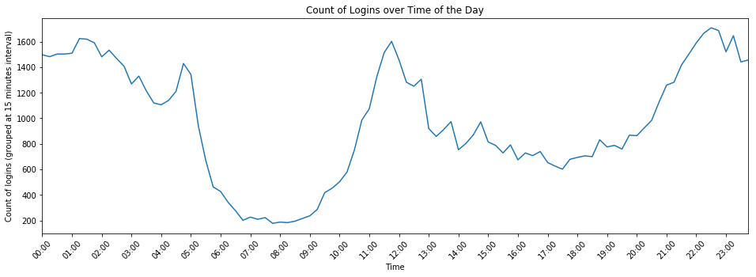

```python
import matplotlib.pyplot as plt
%matplotlib inline
fig = plt.figure(figsize=(16, 5))
time_quarter_login_counts.plot()

plt.xlabel("Time")
plt.ylabel("Count of logins (grouped at 15 minutes interval)")
plt.title("Count of Logins over Time of the Day")
plt.xticks(['00:00:00', '01:00:00', '02:00:00', '03:00:00', '04:00:00',
                '05:00:00', '06:00:00', '07:00:00', '08:00:00', '09:00:00',
                '10:00:00', '11:00:00', '12:00:00', '13:00:00', '14:00:00',
                '15:00:00', '16:00:00', '17:00:00', '18:00:00', '19:00:00',
                '20:00:00', '21:00:00', '22:00:00', '23:00:00'], rotation=45)
plt.ylim();
```

### Count of logins over dates

```python
# Get number of logins for each day
day_login_counts = logins_df['time_quarter'].dt.date.value_counts().sort_index()
day_login_counts
```

```
1970-01-01     106
1970-01-02     680
1970-01-03     790
1970-01-04     796
1970-01-05     459
              ...
1970-04-09     823
1970-04-10    1006
1970-04-11    1353
1970-04-12    1414
1970-04-13     399
Name: time_quarter, Length: 103, dtype: int64
```

```python
# Get date ranges to be used as x-axis label in line chart
pd.period_range('1970-01-01', '1970-04-13')[::3]
```

```
PeriodIndex(['1970-01-01', '1970-01-04', '1970-01-07', '1970-01-10',
             '1970-01-13', '1970-01-16', '1970-01-19', '1970-01-22',
             '1970-01-25', '1970-01-28', '1970-01-31', '1970-02-03',
             '1970-02-06', '1970-02-09', '1970-02-12', '1970-02-15',
             '1970-02-18', '1970-02-21', '1970-02-24', '1970-02-27',
             '1970-03-02', '1970-03-05', '1970-03-08', '1970-03-11',
             '1970-03-14', '1970-03-17', '1970-03-20', '1970-03-23',
             '1970-03-26', '1970-03-29', '1970-04-01', '1970-04-04',
             '1970-04-07', '1970-04-10', '1970-04-13'],
            dtype='period[D]', freq='D')
```

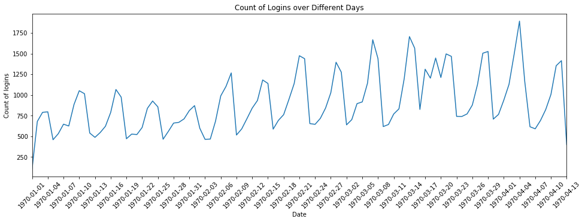

```python
fig = plt.figure(figsize=(16, 5))
day_login_counts.plot()

plt.xlabel("Date")
plt.ylabel("Count of logins")
plt.title("Count of Logins over Different Days")
plt.xticks(['1970-01-01', '1970-01-04', '1970-01-07', '1970-01-10',
             '1970-01-13', '1970-01-16', '1970-01-19', '1970-01-22',
             '1970-01-25', '1970-01-28', '1970-01-31', '1970-02-03',
             '1970-02-06', '1970-02-09', '1970-02-12', '1970-02-15',
             '1970-02-18', '1970-02-21', '1970-02-24', '1970-02-27',
             '1970-03-02', '1970-03-05', '1970-03-08', '1970-03-11',
             '1970-03-14', '1970-03-17', '1970-03-20', '1970-03-23',
             '1970-03-26', '1970-03-29', '1970-04-01', '1970-04-04',
             '1970-04-07', '1970-04-10', '1970-04-13'], rotation=45)
plt.ylim();
```

To further investigate the above cyclical pattern, zoom into only first 15 days period

```python
# Get date ranges to be used as x-axis label in line chart
pd.period_range('1970-01-01', '1970-01-15')
```

```
PeriodIndex(['1970-01-01', '1970-01-02', '1970-01-03', '1970-01-04',
             '1970-01-05', '1970-01-06', '1970-01-07', '1970-01-08',
             '1970-01-09', '1970-01-10', '1970-01-11', '1970-01-12',
             '1970-01-13', '1970-01-14', '1970-01-15'],
            dtype='period[D]', freq='D')
```

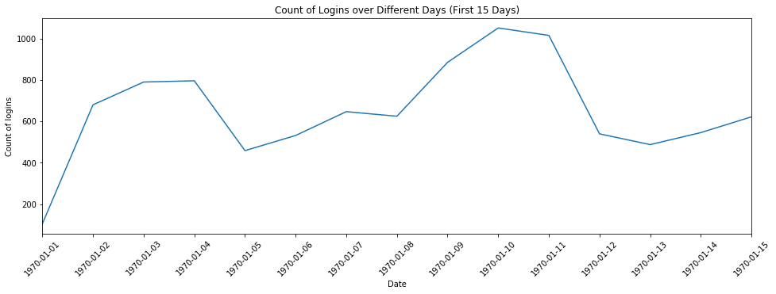

```python
fig = plt.figure(figsize=(16, 5))
day_login_counts[0:15].plot()

plt.xlabel("Date")
plt.ylabel("Count of logins")
plt.title("Count of Logins over Different Days (First 15 Days)")
plt.xticks(['1970-01-01', '1970-01-02', '1970-01-03', '1970-01-04',
             '1970-01-05', '1970-01-06', '1970-01-07', '1970-01-08',
             '1970-01-09', '1970-01-10', '1970-01-11', '1970-01-12',
             '1970-01-13', '1970-01-14', '1970-01-15'], rotation=45);
```

### Count of logins over day of the week

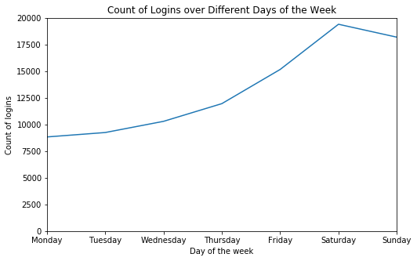

```python
weekday_login_counts = logins_df['time_quarter'].dt.weekday_name.value_counts()[['Monday', 'Tuesday', 'Wednesday',
                                                                            'Thursday','Friday', 'Saturday','Sunday']]
fig = plt.figure(figsize=(8, 5))
weekday_login_counts.plot()

plt.xlabel("Day of the week")
plt.ylabel("Count of logins")
plt.title("Count of Logins over Different Days of the Week")
plt.ylim(0, 20000);
```

```python
# Print count of logins over days of the week
weekday_login_counts
```

```
Monday        8836
Tuesday       9251
Wednesday    10301
Thursday     11963
Friday       15172
Saturday     19415
Sunday       18204
Name: time_quarter, dtype: int64
```

## Experiment and metrics design

A toll bridge, with a two-way toll, between Gotham and Metropolis is main factor that discourages driver partners taking intercity trip. The proposed experiment is aimed at encouraging driver partners to take intercity trips by reimbursing all toll costs.

So to measure the success of proposed experiment, I will track how toll reimbursement changes the proportion of intercity trips in a specified period.

Proportion of intercity trips = Number of intercity trips/Total number of trips

If a driver picks a customer at Gotham, drops off in Metropolis, and then picks another customer in Metropolis and drops off at Gotham, this should be considered as 2 intercity trips. However, if driver go back to Gotham empty, this should be considered as 1 intercity trip. I think this information is easily available in the trip details that is being collected. I also assume that ultimate inc. collect trip-wise detail like pick up point and destination point. This can be used to determine whether a trip is intercity trip (1) or not (0).

**Setting up the experiment, statistical test and interpreting the results**

To set up the experiment, I need some information from Ultimatum Inc. Since this information is not available, I will assume few things.

1. Historically, what is the total number of daily trips and what fraction of these trips is intercity trips. Let me assume that over the past year average daily total trips is 1000 trips and on average 10% of these trips are intercity trips.
2. What % increase in intercity trips will be of practical significance. Let me assume that 1% increase in intercity trips is of practical significance. This is determined based on cost of implementing the toll imbursement and benefit obtained from increase in intercity trips.

My control will be no toll reimbursement. Treatment will be toll imbursement.

Null hypothesis (Ho): % intercity trips when there is toll reimbursement = % intercity trips when there is no toll reimbursement

Alternate hypothesis (H1): % intercity trips when there is toll reimbursement > % intercity trips when there is no toll reimbursement

I can obtain % intercity trips when there is no toll reimbursement from historical data, which is assumed to be 10%. But to control for all extraneous factors, it is a good idea to run both control and treatment almost at the same time. One possibility is to reimburse toll only on alternate day (e.g., On Monday there will be toll reimbursement, Tuesday no reimbursement, Wednesday there will reimbursement so on). We should send notifications to driver in advance and at every day during experiment to inform them what day there will be toll reimbursement and on what day there will be no toll reimbursement.

Next thing is to determine how many days we need to run this experiment. This depends on statistical power we want and standard deviation of the variable. Let me assume that we want 80% power. This means that, if there is indeed 1% increase in intercity trips because of toll reimbursement, we should have a 80% chance of detecting it (80% chance of rejecting null hypothesis).

So, we can use alpha = 5%, Beta (power) = 80%, standard deviation = sqrt(p(1-p) = sqrt(0.1 * 0.9) = 0.3 to calculate minimum number of samples (trips) required for this experiment. This estimation is important since running this experiment could cost a lot of money for Ultimate as they have to reimburse toll.

Number of samples (per group) can be calculated using this formula.

0.01 (practical significance) = 2.8 * SE (standard error)

0.01 = 2.8 * sqrt(0.32/n + 0.32/n)

n = 14,112

So, we need 14,112 x 2 = ~28,000 trips for this experiment. Considering historical average of 1000 trips/day, we need to run this experiment for 28 days. On 14 alternate days we reimburse toll and another 14 days we don’t. The number of trips may not be same during all days historically. We need to account for this so that eventually in both groups we get more or less same number of trips.

Then we can calculate % of intercity trips during tolled and toll-free (toll reimubrsed) days.

Then we can use two sample Z-test (sample size is much larger than 30) to test hypothesis. If the % intercity trips increased more than 1% in treatment, and if it is statistically significant, then we can permanently implement this proposal of reimbursing toll.

## Predictive Modelling

In this section, I will build a model to predict whether or not a user will be active in their 6th month on the system.

```python
# Import data
import json
# Load the data and create a dataframe
with open ("ultimate_data_challenge.json", 'r') as f_in:
    content = f_in.readline()
retention_df = pd.DataFrame(json.loads(content))
retention_df.head()
```

|  | city | trips_in_first_30_days | signup_date | avg_rating_of_driver | avg_surge | last_trip_date | phone | surge_pct | ultimate_black_user | weekday_pct | avg_dist | avg_rating_by_driver |
| --- | --- | --- | --- | --- | --- | --- | --- | --- | --- | --- | --- | --- |
| 0 | King's Landing | 4 | 2014-01-25 | 4.7 | 1.10 | 2014-06-17 | iPhone | 15.4 | True | 46.2 | 3.67 | 5.0 |
| 1 | Astapor | 0 | 2014-01-29 | 5.0 | 1.00 | 2014-05-05 | Android | 0.0 | False | 50.0 | 8.26 | 5.0 |
| 2 | Astapor | 3 | 2014-01-06 | 4.3 | 1.00 | 2014-01-07 | iPhone | 0.0 | False | 100.0 | 0.77 | 5.0 |
| 3 | King's Landing | 9 | 2014-01-10 | 4.6 | 1.14 | 2014-06-29 | iPhone | 20.0 | True | 80.0 | 2.36 | 4.9 |
| 4 | Winterfell | 14 | 2014-01-27 | 4.4 | 1.19 | 2014-03-15 | Android | 11.8 | False | 82.4 | 3.13 | 4.9 |

```python
retention_df.info()
```

```
<class 'pandas.core.frame.DataFrame'>
RangeIndex: 50000 entries, 0 to 49999
Data columns (total 12 columns):
city                      50000 non-null object
trips_in_first_30_days    50000 non-null int64
signup_date               50000 non-null object
avg_rating_of_driver      41878 non-null float64
avg_surge                 50000 non-null float64
last_trip_date            50000 non-null object
phone                     49604 non-null object
surge_pct                 50000 non-null float64
ultimate_black_user       50000 non-null bool
weekday_pct               50000 non-null float64
avg_dist                  50000 non-null float64
avg_rating_by_driver      49799 non-null float64
dtypes: bool(1), float64(6), int64(1), object(4)
memory usage: 4.2+ MB
```

```python
retention_df.describe()
```

|  | trips_in_first_30_days | avg_rating_of_driver | avg_surge | surge_pct | weekday_pct | avg_dist | avg_rating_by_driver |
| --- | --- | --- | --- | --- | --- | --- | --- |
| count | 50000.000000 | 41878.000000 | 50000.000000 | 50000.000000 | 50000.000000 | 50000.000000 | 49799.000000 |
| mean | 2.278200 | 4.601559 | 1.074764 | 8.849536 | 60.926084 | 5.796827 | 4.778158 |
| std | 3.792684 | 0.617338 | 0.222336 | 19.958811 | 37.081503 | 5.707357 | 0.446652 |
| min | 0.000000 | 1.000000 | 1.000000 | 0.000000 | 0.000000 | 0.000000 | 1.000000 |
| 25% | 0.000000 | 4.300000 | 1.000000 | 0.000000 | 33.300000 | 2.420000 | 4.700000 |
| 50% | 1.000000 | 4.900000 | 1.000000 | 0.000000 | 66.700000 | 3.880000 | 5.000000 |
| 75% | 3.000000 | 5.000000 | 1.050000 | 8.600000 | 100.000000 | 6.940000 | 5.000000 |
| max | 125.000000 | 5.000000 | 8.000000 | 100.000000 | 100.000000 | 160.960000 | 5.000000 |

```python
# What are the cities in the data
retention_df.city.value_counts()
```

```
Winterfell        23336
Astapor           16534
King's Landing    10130
Name: city, dtype: int64
```

```python
# Kind of phones used
retention_df.phone.value_counts()
```

```
iPhone     34582
Android    15022
Name: phone, dtype: int64
```

```python
# Number of ultimate_black_user
retention_df.ultimate_black_user.value_counts()
```

```
False    31146
True     18854
Name: ultimate_black_user, dtype: int64
```

```python
# Convert dates to datetime datatype
retention_df['signup_date'] =  pd.to_datetime(retention_df['signup_date'], format='%Y-%m-%d')
retention_df['last_trip_date'] =  pd.to_datetime(retention_df['last_trip_date'], format='%Y-%m-%d')
```

```python
retention_df.info()
```

```
<class 'pandas.core.frame.DataFrame'>
RangeIndex: 50000 entries, 0 to 49999
Data columns (total 12 columns):
city                      50000 non-null object
trips_in_first_30_days    50000 non-null int64
signup_date               50000 non-null datetime64[ns]
avg_rating_of_driver      41878 non-null float64
avg_surge                 50000 non-null float64
last_trip_date            50000 non-null datetime64[ns]
phone                     49604 non-null object
surge_pct                 50000 non-null float64
ultimate_black_user       50000 non-null bool
weekday_pct               50000 non-null float64
avg_dist                  50000 non-null float64
avg_rating_by_driver      49799 non-null float64
dtypes: bool(1), datetime64[ns](2), float64(6), int64(1), object(2)
memory usage: 4.2+ MB
```

```python
# Range of sign up dates (just to make sure both lower and upper range is in January 2014,
# as dataset pertains to users who signed up in Jan 2014.)
min(retention_df['signup_date']), max(retention_df['signup_date'])
```

```
(Timestamp('2014-01-01 00:00:00'), Timestamp('2014-01-31 00:00:00'))
```

```python
# Range of last_trip_date
min(retention_df['last_trip_date']), max(retention_df['last_trip_date'])
```

```
(Timestamp('2014-01-01 00:00:00'), Timestamp('2014-07-01 00:00:00'))
```

#### Determining whether a user is active in their 6th month

Suppose a user sign up on Jan 1st, on June 1st, the user will be into his 6th month. A user is considered to be retained if they were “active” (i.e. took a trip) in the preceding 30 days on any particular date. So if this user book a trip any day on or after May 2nd, he will be considered active.

So, I will add up 5 months to sign up date and then subtract 30 days to get a cut-off date. If the last_trip for the user is on or after this cut-off date, the user will be labelled as 1 (active) and 0 (inactive) otherwise.

```python
retention_df['cutoff_date'] = retention_df['signup_date'] + pd.Timedelta(5, unit='M') - pd.Timedelta(31, unit='D')
# Subtracted 31 days, instead of 30 days, because when I add 5 months to Jan 1st, it becomes June 2
# I used calendar month to calculate 6th month,
# as when we say 6th month, we generally refer to calendar month, not 30 days month

retention_df['is_active'] = (retention_df['last_trip_date'] >= retention_df['cutoff_date']).astype('int')
```

```python
retention_df.head()
```

|  | city | trips_in_first_30_days | signup_date | avg_rating_of_driver | avg_surge | last_trip_date | phone | surge_pct | ultimate_black_user | weekday_pct | avg_dist | avg_rating_by_driver | cutoff_date | is_active |
| --- | --- | --- | --- | --- | --- | --- | --- | --- | --- | --- | --- | --- | --- | --- |
| 0 | King's Landing | 4 | 2014-01-25 | 4.7 | 1.10 | 2014-06-17 | iPhone | 15.4 | True | 46.2 | 3.67 | 5.0 | 2014-05-26 04:25:30 | 1 |
| 1 | Astapor | 0 | 2014-01-29 | 5.0 | 1.00 | 2014-05-05 | Android | 0.0 | False | 50.0 | 8.26 | 5.0 | 2014-05-30 04:25:30 | 0 |
| 2 | Astapor | 3 | 2014-01-06 | 4.3 | 1.00 | 2014-01-07 | iPhone | 0.0 | False | 100.0 | 0.77 | 5.0 | 2014-05-07 04:25:30 | 0 |
| 3 | King's Landing | 9 | 2014-01-10 | 4.6 | 1.14 | 2014-06-29 | iPhone | 20.0 | True | 80.0 | 2.36 | 4.9 | 2014-05-11 04:25:30 | 1 |
| 4 | Winterfell | 14 | 2014-01-27 | 4.4 | 1.19 | 2014-03-15 | Android | 11.8 | False | 82.4 | 3.13 | 4.9 | 2014-05-28 04:25:30 | 0 |

```
0    27753
1    22247
Name: is_active, dtype: int64
```

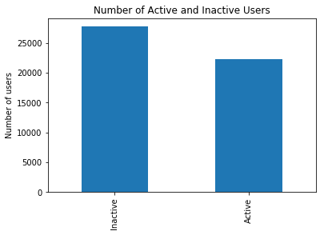

```python
# Number of active customers
import matplotlib.pyplot as plt
print(retention_df['is_active'].value_counts())
retention_df['is_active'].value_counts().plot(kind='bar')
plt.xticks([0, 1], ['Inactive', 'Active'])
plt.ylabel('Number of users')
plt.title("Number of Active and Inactive Users");
```

#### Scatter matrix (relationship among different features)

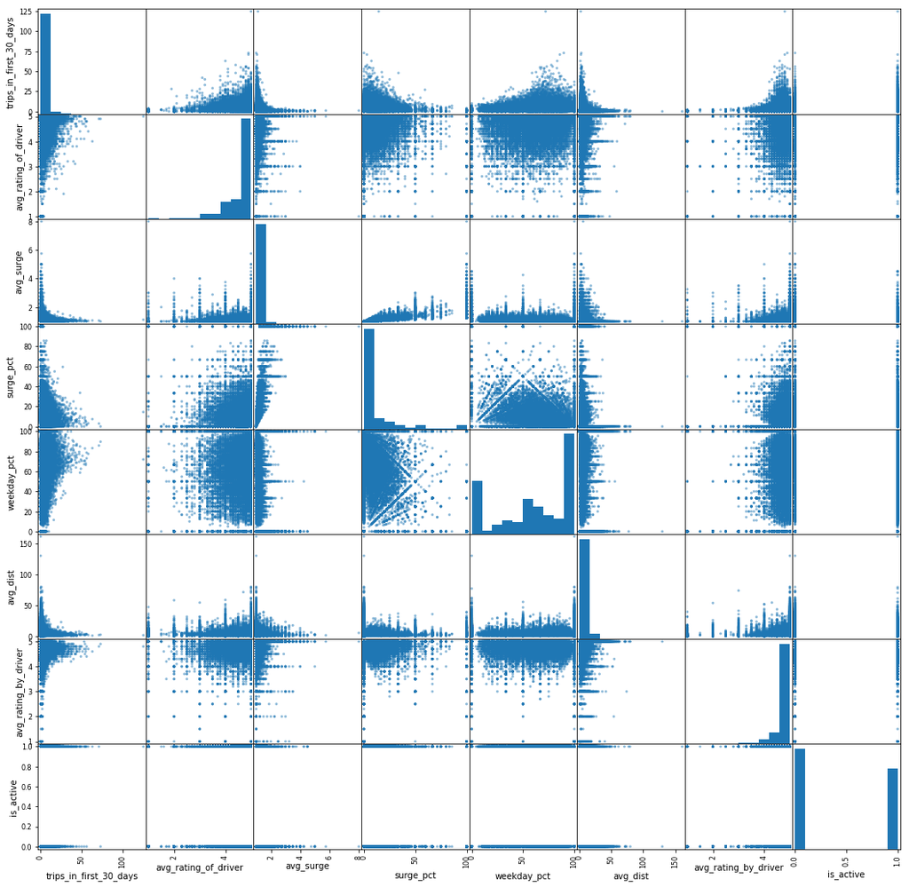

```python
pd.plotting.scatter_matrix(retention_df[['trips_in_first_30_days', 'avg_rating_of_driver', 'avg_surge', 'surge_pct',
'weekday_pct', 'avg_dist', 'avg_rating_by_driver', 'is_active']], figsize=(18,18));
```

```python
# print correlation among feature and target variables
retention_df[['trips_in_first_30_days', 'avg_rating_of_driver', 'avg_surge', 'surge_pct',
'weekday_pct', 'avg_dist', 'avg_rating_by_driver', 'is_active']].corr()
```

|  | trips_in_first_30_days | avg_rating_of_driver | avg_surge | surge_pct | weekday_pct | avg_dist | avg_rating_by_driver | is_active |
| --- | --- | --- | --- | --- | --- | --- | --- | --- |
| trips_in_first_30_days | 1.000000 | -0.011302 | -0.001841 | 0.005720 | 0.050388 | -0.136329 | -0.039115 | 0.180846 |
| avg_rating_of_driver | -0.011302 | 1.000000 | -0.026189 | -0.003899 | 0.014630 | 0.034509 | 0.123175 | -0.011547 |
| avg_surge | -0.001841 | -0.026189 | 1.000000 | 0.793582 | -0.110071 | -0.081491 | 0.010597 | -0.008131 |
| surge_pct | 0.005720 | -0.003899 | 0.793582 | 1.000000 | -0.144918 | -0.104414 | 0.020103 | 0.010780 |
| weekday_pct | 0.050388 | 0.014630 | -0.110071 | -0.144918 | 1.000000 | 0.101652 | 0.020442 | 0.017383 |
| avg_dist | -0.136329 | 0.034509 | -0.081491 | -0.104414 | 0.101652 | 1.000000 | 0.080540 | -0.094193 |
| avg_rating_by_driver | -0.039115 | 0.123175 | 0.010597 | 0.020103 | 0.020442 | 0.080540 | 1.000000 | -0.026006 |
| is_active | 0.180846 | -0.011547 | -0.008131 | 0.010780 | 0.017383 | -0.094193 | -0.026006 | 1.000000 |

### Characterstics of the dataset

There are 50,000 records in this dataset. The target label (whether an user is active in his/her 6th month or not) is little imbalanced. 55% of the users are inactive. There are some missing values in the columns avg_rating_of_driver, phone, avg_rating_by_driver. More than 68% of the users seem to be using iPhone app. I did not find a significant correlation among features except between avg_surge and surge_pct, which have a correlation of 0.8.

### Handling missing values

Impute missing value with mean (numerical variable) or mode (categorical variable) of the feature

```python
# Fill na with mean (numerical variable) or mode (categorical variable)
retention_df['avg_rating_of_driver'] = (retention_df['avg_rating_of_driver']
                                        .fillna(retention_df['avg_rating_of_driver'].mean()))
retention_df['avg_rating_by_driver'] = (retention_df['avg_rating_by_driver']
                                        .fillna(retention_df['avg_rating_by_driver'].mean()))
retention_df['phone'] = (retention_df['phone']
                                        .fillna(retention_df['phone'].mode()[0]))
```

```python
retention_df.info()
retention_df['phone'].mode()
```

```
<class 'pandas.core.frame.DataFrame'>
RangeIndex: 50000 entries, 0 to 49999
Data columns (total 14 columns):
city                      50000 non-null object
trips_in_first_30_days    50000 non-null int64
signup_date               50000 non-null datetime64[ns]
avg_rating_of_driver      50000 non-null float64
avg_surge                 50000 non-null float64
last_trip_date            50000 non-null datetime64[ns]
phone                     50000 non-null object
surge_pct                 50000 non-null float64
ultimate_black_user       50000 non-null bool
weekday_pct               50000 non-null float64
avg_dist                  50000 non-null float64
avg_rating_by_driver      50000 non-null float64
cutoff_date               50000 non-null datetime64[ns]
is_active                 50000 non-null int32
dtypes: bool(1), datetime64[ns](3), float64(6), int32(1), int64(1), object(2)
memory usage: 4.8+ MB
```

```
0    iPhone
dtype: object
```

### Which features to use in model training

We definitely need to remove sign_up date and last_trip date as if we include these variables, we are going to encode target variables in the feature itself. There is a strong correlation (0.8) between avg_surge and surge_pct. So, it is a good idea to remove one of these variables. Since surge_pct has slightly higher correlation with the target variable, I will remove avg_surge. It should be noted that the target variable does not seem to have a strong correlation with any of the predictors. Let us see how our model is going perform.

```python
# Prepare features and target variables
features = retention_df.drop(['is_active', 'signup_date', 'last_trip_date', 'avg_surge', 'cutoff_date'], axis=1)
target = retention_df['is_active']
```

```python
# One hot encode categorical variables
features_final = pd.get_dummies(features)
features_final.head()
```

|  | trips_in_first_30_days | avg_rating_of_driver | surge_pct | ultimate_black_user | weekday_pct | avg_dist | avg_rating_by_driver | city_Astapor | city_King's Landing | city_Winterfell | phone_Android | phone_iPhone |
| --- | --- | --- | --- | --- | --- | --- | --- | --- | --- | --- | --- | --- |
| 0 | 4 | 4.7 | 15.4 | True | 46.2 | 3.67 | 5.0 | 0 | 1 | 0 | 0 | 1 |
| 1 | 0 | 5.0 | 0.0 | False | 50.0 | 8.26 | 5.0 | 1 | 0 | 0 | 1 | 0 |
| 2 | 3 | 4.3 | 0.0 | False | 100.0 | 0.77 | 5.0 | 1 | 0 | 0 | 0 | 1 |
| 3 | 9 | 4.6 | 20.0 | True | 80.0 | 2.36 | 4.9 | 0 | 1 | 0 | 0 | 1 |
| 4 | 14 | 4.4 | 11.8 | False | 82.4 | 3.13 | 4.9 | 0 | 0 | 1 | 1 | 0 |

```python
# Import train_test_split
from sklearn.model_selection import train_test_split

# Split the 'features' and 'income' data into training and testing sets
X_train, X_test, y_train, y_test = train_test_split(features_final,
                                                    target,
                                                    test_size = 0.25,
                                                    random_state = 0)

# Show the results of the split
print("Training set has {} samples.".format(X_train.shape[0]))
print("Testing set has {} samples.".format(X_test.shape[0]))
```

```
Training set has 37500 samples.
Testing set has 12500 samples.
```

### Naive Bayes (as a benchmark model)

```python
from sklearn.metrics import f1_score, make_scorer, accuracy_score, classification_report
from sklearn.naive_bayes import GaussianNB

clf = GaussianNB()

# Fit the new model.
clf.fit(X_train, y_train)
test_predictions = clf.predict(X_test)

test_accuracy = round(accuracy_score(y_test, test_predictions), 2)
test_f1 = round(f1_score(y_test, test_predictions), 2)

print (f'Test accuracy: {test_accuracy}')
print (f'Test f1: {test_f1}')
```

```
Test accuracy: 0.68
Test f1: 0.65
```

### XGBoost

XGBoost is an ensemble method that is known to perform well on many datasets. Boosting sequentially converts weak learners into strong learners by correcting the classification errors of previous weak learner in the sequence. Since XGBoost intrinsically handle class imbalance, it is useful in this case as there is a slight class imbalance. As it is a tree based method, feature scaling is not necessary. Furthermore, this algorithm is optimized for parallel computing, so that I can use multi cores for training.

```python
from xgboost import XGBClassifier
# XGBoost with tuned hyperparameters
clf = XGBClassifier(random_state=42)
```

### Cross validation

```python
from sklearn.model_selection import GridSearchCV
from sklearn.metrics import f1_score, make_scorer, accuracy_score, classification_report
# XGBoost with tuned hyperparameters
clf = XGBClassifier(random_state=42)

params = {'max_depth': [3, 5, 10],
              'n_estimators' : [100, 200]}

# Make an f1_score scoring object.
# Since classes are imbalanced, I used f1_score. But tried accuracy also and gave almost the same result
scorer = make_scorer(f1_score)

# Perform grid search on the classifier using 'scorer' as the scoring method.
grid_obj = GridSearchCV(clf, params, scoring=scorer)


# Fit the grid search object to the training data and find the optimal parameters.
grid_fit = grid_obj.fit(X_train, y_train)

# Get the estimator.
clf = grid_fit.best_estimator_

# Fit the new model.
clf.fit(X_train, y_train)

# Print best parmeters
print(f"Best parameters: {grid_fit.best_params_}")

test_predictions = clf.predict(X_test)

test_accuracy = round(accuracy_score(y_test, test_predictions), 2)
test_f1 = round(f1_score(y_test, test_predictions), 2)

print (f'Test accuracy: {test_accuracy}')
print (f'Test f1: {test_f1}')
```

[output not shown]

[output cut: 17 more lines]

[output not shown]

```
Best parameters: {'max_depth': 5, 'n_estimators': 200}
Test accuracy: 0.78
Test f1: 0.73
```

```python
print(classification_report(y_test, test_predictions, target_names=['Not Active', 'Is active']))
```

```
             precision    recall  f1-score   support

 Not Active       0.77      0.84      0.81      6930
  Is active       0.78      0.69      0.73      5570

avg / total       0.78      0.78      0.77     12500
```

## Conclusion

I bulild a XGBoost model to predict whether an user will be active in his/her 6th month. This model has an accuracy of 78% and f1 score of 73%. This is significant improvement over benchmark Naive Bayes model, which has an accuracy of 68% and f1 score of 65%. This model can be used by Ultimate Inc. to predict customer churn. They can offer some discounts to the customers who are not likely to be retained.